# Case Study Beer EDA

## R Markdown

Bring in Data

```r
Beers_df=read.csv(file.choose(),header=TRUE)
Breweries_df=read.csv(file.choose(),header=TRUE)
```

Question 1: How many breweries are present in each state?

```
##   State count
## 1    AK     7
## 2    AL     3
```

Question 2 Merge beer data with the breweries data. Print the first 6 observations and the last six observations to check the merged file. (RMD only, this does not need to be included in the presentation or the deck.)

```
##   Brewery_id          Name Beer_ID   ABV IBU              Style Ounces
## 1          1  Get Together    2692 0.045  50       American IPA     16
## 2          1 Maggie's Leap    2691 0.049  26 Milk / Sweet Stout     16
##      Brewery_id.Name        City State
## 1 NorthGate Brewing  Minneapolis    MN
## 2 NorthGate Brewing  Minneapolis    MN
```

## Including Plots

Question 3: Address the missing values in each column.

```r
CombinedData[CombinedData=='']<-NA

colSums(is.na(CombinedData))
```

```
##      Brewery_id            Name         Beer_ID             ABV             IBU
##               0               0               0              62            1005
##           Style          Ounces Brewery_id.Name            City           State
##               5               0               0               0               0
```

```r
#changed #NA to 0 to get actual medians
CombinedData[is.na(CombinedData)]<-0
#created the dataframes with medians for each State
Medians<-CombinedData%>%group_by(State)%>%summarise(median.ABV=median(ABV),median.IBU=median(IBU))

head(Medians,6)
```

```
## # A tibble: 6 x 3
##   State median.ABV median.IBU
##   <fct>      <dbl>      <dbl>
## 1 " AK"      0.056       17
## 2 " AL"      0.06        39.5
## 3 " AR"      0.052        0
## 4 " AZ"      0.055        9
## 5 " CA"      0.058       28
## 6 " CO"      0.059       17
```

Question 5: Which state has the maximum alcoholic (ABV) beer? Which state has the most bitter (IBU) beer?

the state with the highest ABV = Colorado the state with the highest IBU = Oregon

```r
Maximum<-CombinedData%>%group_by(State)%>%summarise(Max.ABV=max(ABV),Max.IBU=max(IBU))

head(Maximum,5)
```

```
## # A tibble: 5 x 3
##   State Max.ABV Max.IBU
##   <fct>   <dbl>   <dbl>
## 1 " AK"   0.068      71
## 2 " AL"   0.093     103
## 3 " AR"   0.061      39
## 4 " AZ"   0.095      99
## 5 " CA"   0.099     115
```

Question 6: Comment on the summary statistics and distribution of the ABV variable.

```r
CombinedData[CombinedData==0]<-NA

summary(CombinedData$ABV)
```

```
##    Min. 1st Qu.  Median    Mean 3rd Qu.    Max.    NA's
## 0.00100 0.05000 0.05600 0.05977 0.06700 0.12800      62
```

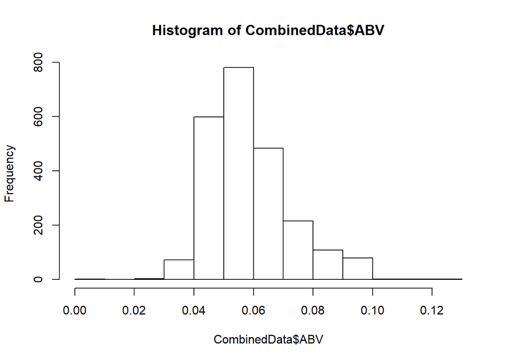

```r
hist(CombinedData$ABV)
```

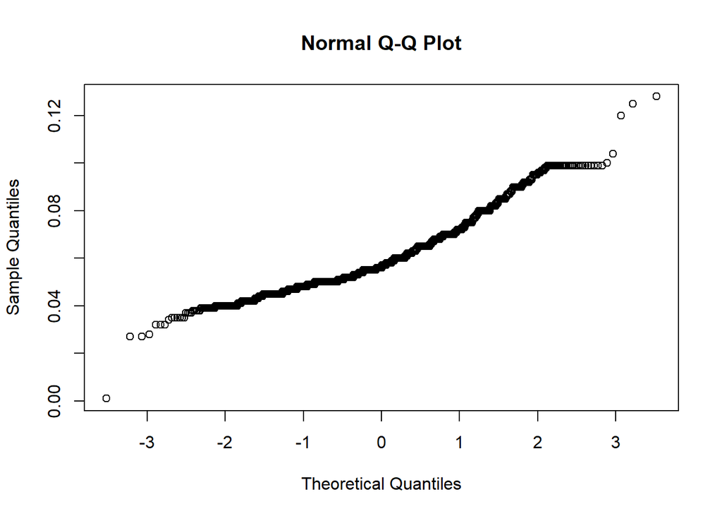

```r
qqnorm(CombinedData$ABV)
```

Question 7: Is there an apparent relationship between the bitterness of the beer and its alcoholic content? Draw a scatt10er plot. Make your best judgment of a relationship and EXPLAIN your answer.

[figure not shown]

```r
plot(CombinedData$ABV,CombinedData$IBU,pch = 15,xlab = "Alcoholic Content",ylab = "Bittternes", main = "Alcohol vs Bitternes")
```